# Explainable AI: The next Big thing you should know

$\hspace{1cm}$

*Alan Chau*

*DPhil in Statistical Machine Learning @ University of Oxford*

## About me

- Research interests: Kernel methods $\cap$ {Preferential Learning, Graph ML, Explainable AI}
- Work interests: Freelance Data Science and ML consultant with experiences in a variety of domain, e.g Fashion, Fintech and Argritech.
- Human interests: Brewing coffee ☕ , chess ♟️ and singing 🎤.

Machine Learning is not just about prediction...

We have more ...

For example,

- Experimental design
- Causal reasoning
- Data visualisation
- Machine Learning on irregular data domain, such as text, graphs and videos.
- **Explainable AI (X-AI)**

## What is Explainable AI and why do we care?

$\hspace{1cm}$

- Explainable AI $\Rightarrow$ Model Inspection and interpretation techniques.
- A few reasons from *Samek et al (2017)* summarising why we should care:
  1. Verification of the system
  2. Improvment of the system
  3. Learning from the system
  4. Compliance to legislation

## Three applications of XAI we will go through today

1. Quantifying uncertainty in predictions
   - *Gaussian Processes*
2. Attributing importance scores to features
   - *Model coefficients, tree split ratios, SHAP, SAGE*
3. Handling what-if situations
   - *Counterfactual modelling*

### Quantifying uncertainity in predictions: Gaussian Processes

Quantify how certain your prediction is easily.

[figure not shown]

### Definition

We say $f \sim GP(m, k)$ is a Gaussian Process with mean function $m$ and covariance function $k$ if for any finite collections of data $\{X_t\}_{t=1}^n$, the vector $\mathbf{f}= [f(X_1), ... ,f(X_n)]^\top$ is a multivariate normal distribution:

\begin{equation} \mathbf{f} \sim N(\mathbf{m}, \mathbf{K}) \end{equation}

where,

\begin{align} {\bf m} &= [m(X_1), ..., m(X_n)]^\top \\ {\bf K}_{i,j} &= k(X_i, X_j) \end{align}

is the evaluated mean and covariance structure using the data $\{X_t\}_{t=1}^n$.

### Gaussian Process Regression

Given dataset $D_1 = \{(x_i, y_i)\}_{i=1}^n$, similar to how we postulate a model for linear regression:

\begin{equation} {\bf y} = {\bf X}\beta + \epsilon \quad \epsilon \sim N(0, \sigma^2) \end{equation}

where $\bf X$ is the design matrix of size $n\times d$ and ${\bf y}$ is the vector of outputs. We can do the same for Gaussian Process Regression (GPR) and set:

\begin{align} {\bf y} = {\bf f} + \epsilon \quad \epsilon \sim N(0, \sigma^2 I) \end{align}

with $\mathbf{f}= [f(X_1), ... ,f(X_n)]^\top$.

### Inference

Once the model is established, we now have completely specification of the model, aka we have $p(y)$ and $p(f)$ and we apply the Gaussian conditioning rule:

#### Gaussian conditioning

Let $\mathbf{z} \sim \mathcal{N}(\mu, \Sigma)$ be a multivariate normal random vector and let us split its dimensions into two parts, i.e.

$$ \mathbf{z}=\left[\begin{array}{l} \mathbf{z}_{1} \\ \mathbf{z}_{2} \end{array}\right], \quad \mu=\left[\begin{array}{l} \mu_{1} \\ \mu_{2} \end{array}\right], \quad \Sigma=\left[\begin{array}{ll} \Sigma_{11} & \Sigma_{12} \\ \Sigma_{21} & \Sigma_{22} \end{array}\right] $$

Note that $\Sigma_{21}=\Sigma_{12}^{\top}$ due to symmetry of covariance matrices. Then the conditional density of $\mathbf{z}_{2}$ given $\mathbf{z}_{1}$ is also normal and given by

$$ p\left(\mathbf{z}_{2} \mid \mathbf{z}_{1}\right)=\mathcal{N}\left(\mathbf{z}_{2} ; \mu_{2}+\Sigma_{21} \Sigma_{11}^{-1}\left(\mathbf{z}_{1}-\mu_{1}\right), \Sigma_{22}-\Sigma_{21} \Sigma_{11}^{-1} \Sigma_{12}\right) $$

### TL:DR

and as a result, we have

\begin{equation} \mathbf{f} \mid \mathbf{y} \sim \mathcal{N}\left(\mathbf{K}\left(\mathbf{K}+\sigma^{2} I\right)^{-1} \mathbf{y}, \mathbf{K}-\mathbf{K}\left(\mathbf{K}+\sigma^{2} I\right)^{-1} \mathbf{K}\right) \end{equation}

```python
# Load Pacakges
import numpy as np
import matplotlib.pylab as plt
import seaborn as sns

from sklearn.gaussian_process import GaussianProcessRegressor
from sklearn.gaussian_process.kernels import RBF, WhiteKernel
```

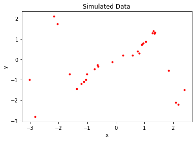

```python
# Simulate some data
n, noise = 30, 0.1
x, y = generate_GP_simulation(n, noise)

plt.plot(x, y, "r.")
plt.xlabel("x"), plt.ylabel("y"), plt.title("Simulated Data")
plt.show()
```

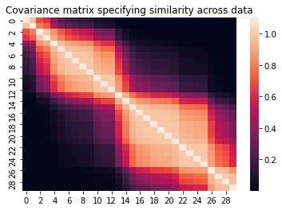

```python
# Set up the kernel function
kernel_ = RBF(length_scale=1.) + WhiteKernel(noise_level=noise)

# Visualise the kernel matrix
K = kernel_(x.reshape(-1, 1))
sns.heatmap(K)
plt.title("Covariance matrix specifying similarity across data")
plt.show()
```

### Fitting a GPR in sklearn is easy!

```python
# Set up the GPR object and fit
gpr = GaussianProcessRegressor(kernel=kernel_)
gpr.fit(x.reshape(-1, 1), y)
```

```
GaussianProcessRegressor(alpha=1e-10, copy_X_train=True,
                         kernel=RBF(length_scale=1) + WhiteKernel(noise_level=0.1),
                         n_restarts_optimizer=0, normalize_y=False,
                         optimizer='fmin_l_bfgs_b', random_state=None)
```

### Retreiving predictions and uncertainties are also easy!

```python
# Set up x_test
x_test = np.linspace(np.min(x)-2, np.max(x)+2, 300)

# Run your prediction and retrieve the mean and uncertainity
y_pred, y_std = gpr.predict(x_test.reshape(-1, 1), return_std=True)
```

### Finally, let us obtain a visualisation

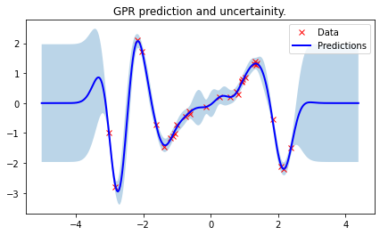

```python
# Visualisation
plot_result(x, y, x_test, y_pred, y_std)
```

## GP Summary

1. A flexible regression method (can do classification too)
2. Provides uncertainity estimation to your predictions.
3. However, these extra functionalities come with a price to pay: need $O(n^3)$ to run exact GPR. (There are ways around it though).

P.S **sklearn** is just a quick way to implement GP but one should really learn how to use **gpytorch** instead.

## Quantifying feature importance: SHAP and SAGE

[figure not shown]

Image credit: Scott Lundberg

## SHAP (Shapley Additive exPlanation)

- SHAP is a game theoretic approach to quantify feature's contribution to the output of **any** machine learning model.
- The idea stems from cooperative game theory in which we want to quantify how important a player is in a cooperative game.

## Origin story

Given a value function $v$ that takes in any combination of players $\mathcal{I} = \{1, ..., m\}$ and output some scores. If we were interested in quantifying the importance of player $i$, we do the following,

1. Fix a set of collaborators, e.g $S = \{1, 3, 5\}$ and compute the marginal improvement if player $i$ is included in the game with collaborators $S$,

\begin{align} \delta_i(S) = v(S\cup i) - v(S) \end{align}

1. Loop through all possible sets of collaborators S from the power set of $\mathcal{I} \backslash \{i\}$ and compute $\delta_i(S)$
2. Compute the weighted average : \begin{align} \phi_i = \sum_{S \subseteq \mathcal{I}\backslash \{i\}} p_{|\mathcal{I}|, |S|} \delta_i(S) \end{align}

where the weight is a function of the number of players and the number of collaborators. $\phi_i$ is known as the $\textbf{Shapley Value}$ of player $i$.

## Connection to Machine learning models

To represent machine learning models as a collaborative game we need to clarify the following:

1. Who are the players?
2. What is the value function?

### Players

- features $\Omega = \{1, .., m\} $used in prediction

### Value functions

For a given function $f: x \mapsto f(x)$,

- $v(S) = \mathbb{E}[f(X)|S] \quad S \subseteq \Omega$

where conditioning on $S$ means considering the input X to be a random variable where features in $S$ are known. In fact, different choices of the value functions will lead to different interepration of the importance score.

## Why Shapley Values?

There are different feature importance scoring techniques, for example:

1. Examining coefficients of a linear model (Linear regression)
2. Looking at the frequency of being included as a splitting criteria for tree models (Random forest)
3. Examine the lengthscale in the ARD kernel (Kernel Methods)

However, these are all global feature importance scores, meaning they cannot provide local feature importance.

- e.g. For a given patient, which biomarker contributed most to estimating his organ failure in 2 months?

## Shapley Values is principled.

Shapley values are well studied objects for almost half a decade because it possess some very "nice" properties. One that is particular appealing to us is the fact that: For a given input $x$,

\begin{align} \sum_{j=1}^m \phi_j = f(x_j) \end{align}

the sum of the importance scores at each feature equates the model predictions.

## Computing Shapley Values effectively

- In 2017, Lundberg et. al proposed KernelSHAP, a computationally effective algorithm to compute Shapley values as the solution weighted least square problem.

```python
# Import packages
import numpy as np
import matplotlib.pylab as plt

import shap

from sklearn.ensemble import RandomForestRegressor
```

```python
shap.initjs()

X, y = shap.datasets.boston()

rf = RandomForestRegressor(n_estimators=500)
rf.fit(X, y)

explainer = shap.KernelExplainer(rf.predict, shap.sample(X, 10))
shap_values = explainer.shap_values(X.iloc[:30,:], nsamples=50)
```

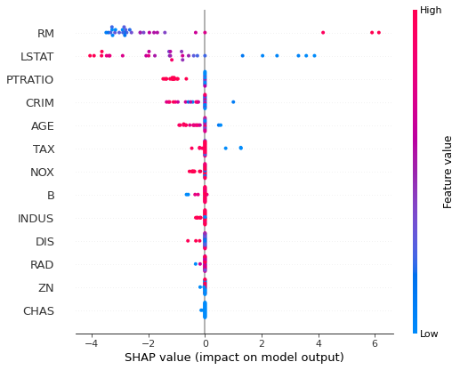

```python
shap.summary_plot(shap_values, X.iloc[:30, :])
```

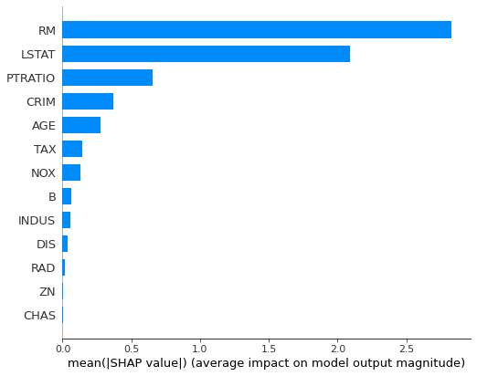

```python
shap.summary_plot(shap_values, X.iloc[:30, :], plot_type="bar")
```